# Microft Grab Competition for Safety Predictions

[figure not shown]

- I. Importing Libraries
- II. Read Data
- III. Data Visualization and Feature Engineering
  - Excluding Outliers
- IV. Machine Learning Model Training
- V. Machine Learning Model Tuning
  - Manual Tuning
  - RandomSearchCV Tuning
- VI. Machine Learning Model Evaluation
- VII. Deep Learning Model Training
- VIII. Deep Learning Model Tuning
- IX. Deep Learning Model Evaluation

# I. Import Libraries

```python
import tensorflow as tf
import numpy as np
from tensorflow.keras import backend as K
import matplotlib.pyplot as plt
from sklearn.metrics import classification_report
from tensorflow.keras.datasets import mnist
import numpy
from sklearn.preprocessing import scale
import pandas as pd
from tensorflow.keras.callbacks import EarlyStopping
from keras.layers.normalization import BatchNormalization
from tensorflow.keras.datasets import mnist
from sklearn.model_selection import train_test_split
from tensorflow.keras.models import Sequential
import seaborn as sns
from tensorflow.keras.layers import Dense
from tensorflow.keras.layers import Dropout
from tensorflow.keras.layers import Flatten
from sklearn.preprocessing import StandardScaler
from tensorflow.keras import backend as K
from tensorflow.keras.layers import Dense
from tensorflow.keras.layers import BatchNormalization
from tensorflow.keras.wrappers.scikit_learn import KerasClassifier
import warnings
import matplotlib.pyplot as plt
from sklearn.neighbors import KNeighborsClassifier
import seaborn as sns
import pandas as pd
import numpy as np
from sklearn.metrics import plot_confusion_matrix
from sklearn.svm import SVC
from sklearn.model_selection import cross_val_score, KFold, cross_val_predict
import sklearn.ensemble as ske
import matplotlib
from sklearn.metrics import mean_absolute_error
from sklearn.model_selection import train_test_split
from sklearn.impute import SimpleImputer
from sklearn.metrics import mean_absolute_error, confusion_matrix
from sklearn.tree import DecisionTreeRegressor, DecisionTreeClassifier
from sklearn.multiclass import OneVsRestClassifier
from sklearn.linear_model import PassiveAggressiveClassifier, LinearRegression, LogisticRegression
from sklearn.dummy import DummyClassifier
from sklearn.naive_bayes import GaussianNB
from sklearn.ensemble import BaggingClassifier, ExtraTreesClassifier, AdaBoostClassifier, GradientBoostingClassifier, RandomForestClassifier
from sklearn.preprocessing import StandardScaler, OneHotEncoder, LabelEncoder
from sklearn.metrics import confusion_matrix
from sklearn.model_selection import RandomizedSearchCV
from sklearn.gaussian_process import GaussianProcessClassifier
warnings.filterwarnings("ignore")
pd.set_option('float_format','{:f}'.format)
```

# II. Read data

```python
df1=pd.read_csv('https://msftgrab.z23.web.core.windows.net/safety/features/part-00000-e6120af0-10c2-4248-97c4-81baf4304e5c-c000.csv')
df2=pd.read_csv('https://msftgrab.z23.web.core.windows.net/safety/features/part-00001-e6120af0-10c2-4248-97c4-81baf4304e5c-c000.csv')
df3=pd.read_csv('https://msftgrab.z23.web.core.windows.net/safety/features/part-00002-e6120af0-10c2-4248-97c4-81baf4304e5c-c000.csv')
df4=pd.read_csv('https://msftgrab.z23.web.core.windows.net/safety/features/part-00003-e6120af0-10c2-4248-97c4-81baf4304e5c-c000.csv')
df5=pd.read_csv('https://msftgrab.z23.web.core.windows.net/safety/features/part-00004-e6120af0-10c2-4248-97c4-81baf4304e5c-c000.csv')
df6=pd.read_csv('https://msftgrab.z23.web.core.windows.net/safety/features/part-00005-e6120af0-10c2-4248-97c4-81baf4304e5c-c000.csv')
df7=pd.read_csv('https://msftgrab.z23.web.core.windows.net/safety/features/part-00006-e6120af0-10c2-4248-97c4-81baf4304e5c-c000.csv')
df8=pd.read_csv('https://msftgrab.z23.web.core.windows.net/safety/features/part-00007-e6120af0-10c2-4248-97c4-81baf4304e5c-c000.csv')
df9=pd.read_csv('https://msftgrab.z23.web.core.windows.net/safety/features/part-00008-e6120af0-10c2-4248-97c4-81baf4304e5c-c000.csv')
df10=pd.read_csv('https://msftgrab.z23.web.core.windows.net/safety/features/part-00009-e6120af0-10c2-4248-97c4-81baf4304e5c-c000.csv')
df_label=pd.read_csv('https://msftgrab.z23.web.core.windows.net/safety/labels/part-00000-e9445087-aa0a-433b-a7f6-7f4c19d78ad6-c000.csv')
```

Concatenate data into one dataframe

```python
# Use pd.concat to concatenate the dataframes
df_features = pd.concat([df1,df2,df3,df4,df5,df6,df7,df8,df9,df10])
```

Display the head of the features dataframe

```python
df_features.head()
```

|  | bookingID | Accuracy | Bearing | acceleration_x | acceleration_y | acceleration_z | gyro_x | gyro_y | gyro_z | second | Speed |
| --- | --- | --- | --- | --- | --- | --- | --- | --- | --- | --- | --- |
| 0 | 1202590843006 | 3.000000 | 353.000000 | 1.228867 | 8.900100 | 3.986968 | 0.008221 | 0.002269 | -0.009966 | 1362.000000 | 0.000000 |
| 1 | 274877907034 | 9.293000 | 17.000000 | 0.032775 | 8.659933 | 4.737300 | 0.024629 | 0.004028 | -0.010858 | 257.000000 | 0.190000 |
| 2 | 884763263056 | 3.000000 | 189.000000 | 1.139675 | 9.545974 | 1.951334 | -0.006899 | -0.015080 | 0.001122 | 973.000000 | 0.667059 |
| 3 | 1073741824054 | 3.900000 | 126.000000 | 3.871543 | 10.386364 | -0.136474 | 0.001344 | -0.339601 | -0.017956 | 902.000000 | 7.913285 |
| 4 | 1056561954943 | 3.900000 | 50.000000 | -0.112882 | 10.550960 | -1.560110 | 0.130568 | -0.061697 | 0.161530 | 820.000000 | 20.419409 |

Display the statical description for each column. For most of the columns, we can see that the min, max and mean valeus differ by a lot. We will normalize the data by excluding outliers later on.

```python
pd.set_option('float_format', '{:f}'.format)
```

```python
df_features.describe()
```

|  | bookingID | Accuracy | Bearing | acceleration_x | acceleration_y | acceleration_z | gyro_x | gyro_y | gyro_z | second | Speed |
| --- | --- | --- | --- | --- | --- | --- | --- | --- | --- | --- | --- |
| count | 16135561.000000 | 16135561.000000 | 16135561.000000 | 16135561.000000 | 16135561.000000 | 16135561.000000 | 16135561.000000 | 16135561.000000 | 16135561.000000 | 16135561.000000 | 16135561.000000 |
| mean | 818481856593.303833 | 11.610352 | 168.968356 | 0.069145 | 4.468976 | 0.894297 | -0.001711 | 0.000280 | -0.000257 | 3803.484183 | 9.006543 |
| std | 495247577197.329651 | 86.916720 | 107.296610 | 1.424161 | 8.130664 | 3.251549 | 0.144562 | 0.340063 | 0.148082 | 1436686.492878 | 8.106415 |
| min | 0.000000 | 0.750000 | 0.000000 | -78.419685 | -72.994119 | -78.448420 | -48.455750 | -74.888610 | -53.554450 | 0.000000 | -2.000000 |
| 25% | 377957122222.000000 | 3.900000 | 78.000000 | -0.508124 | -2.022476 | -0.931610 | -0.026789 | -0.029939 | -0.018765 | 241.000000 | 1.020000 |
| 50% | 807453851666.000000 | 4.250000 | 168.870041 | 0.061371 | 9.081485 | 0.775745 | -0.000643 | 0.000265 | -0.000035 | 520.000000 | 7.530000 |
| 75% | 1254130450445.000000 | 8.000000 | 262.984039 | 0.635062 | 9.709778 | 2.750938 | 0.023306 | 0.031431 | 0.018234 | 863.000000 | 15.480000 |
| max | 1709396983975.000000 | 6070.101000 | 359.999481 | 66.873456 | 75.055885 | 78.055756 | 39.839750 | 80.314964 | 66.300780 | 1495796757.000000 | 148.018630 |

11 columns, too many rows, we will group the data using mean by bookingID

```python
df_features.shape
```

```
(16135561, 11)
```

We want to keep as many information as possible, so we will store the counts of the bookingID before grouping them

```python
id_counts = df_features['bookingID'].value_counts() # value counts of each booking ID
```

Instead of setting bookingID the index, we want to make it into a column for merging later

```python
id_counts = id_counts.reset_index(level=0)
```

```python
id_counts.head()
```

|  | index | bookingID |
| --- | --- | --- |
| 0 | 438086664371 | 7561 |
| 1 | 1374389534819 | 4499 |
| 2 | 34359738469 | 4302 |
| 3 | 1108101562533 | 3925 |
| 4 | 747324309632 | 3674 |

Rename the columns

```python
id_counts = id_counts.rename(columns={'index':'bookingID','bookingID':'booking_counts'})
```

```python
id_counts.head()
```

|  | bookingID | booking_counts |
| --- | --- | --- |
| 0 | 438086664371 | 7561 |
| 1 | 1374389534819 | 4499 |
| 2 | 34359738469 | 4302 |
| 3 | 1108101562533 | 3925 |
| 4 | 747324309632 | 3674 |

Merge the features with booking_counts dataframe now there are 12 columns

```python
df_features = pd.merge(df_features,id_counts,how='left',on='bookingID') # We should use right join or otherwise there will be features will null labels.
df_features.head()
```

|  | bookingID | Accuracy | Bearing | acceleration_x | acceleration_y | acceleration_z | gyro_x | gyro_y | gyro_z | second | Speed | booking_counts |
| --- | --- | --- | --- | --- | --- | --- | --- | --- | --- | --- | --- | --- |
| 0 | 1202590843006 | 3.000000 | 353.000000 | 1.228867 | 8.900100 | 3.986968 | 0.008221 | 0.002269 | -0.009966 | 1362.000000 | 0.000000 | 1151 |
| 1 | 274877907034 | 9.293000 | 17.000000 | 0.032775 | 8.659933 | 4.737300 | 0.024629 | 0.004028 | -0.010858 | 257.000000 | 0.190000 | 1610 |
| 2 | 884763263056 | 3.000000 | 189.000000 | 1.139675 | 9.545974 | 1.951334 | -0.006899 | -0.015080 | 0.001122 | 973.000000 | 0.667059 | 1677 |
| 3 | 1073741824054 | 3.900000 | 126.000000 | 3.871543 | 10.386364 | -0.136474 | 0.001344 | -0.339601 | -0.017956 | 902.000000 | 7.913285 | 1044 |
| 4 | 1056561954943 | 3.900000 | 50.000000 | -0.112882 | 10.550960 | -1.560110 | 0.130568 | -0.061697 | 0.161530 | 820.000000 | 20.419409 | 900 |

```python
df_features.shape
```

```
(16135561, 12)
```

```python
df_features.head()
```

|  | bookingID | Accuracy | Bearing | acceleration_x | acceleration_y | acceleration_z | gyro_x | gyro_y | gyro_z | second | Speed | booking_counts |
| --- | --- | --- | --- | --- | --- | --- | --- | --- | --- | --- | --- | --- |
| 0 | 1202590843006 | 3.000000 | 353.000000 | 1.228867 | 8.900100 | 3.986968 | 0.008221 | 0.002269 | -0.009966 | 1362.000000 | 0.000000 | 1151 |
| 1 | 274877907034 | 9.293000 | 17.000000 | 0.032775 | 8.659933 | 4.737300 | 0.024629 | 0.004028 | -0.010858 | 257.000000 | 0.190000 | 1610 |
| 2 | 884763263056 | 3.000000 | 189.000000 | 1.139675 | 9.545974 | 1.951334 | -0.006899 | -0.015080 | 0.001122 | 973.000000 | 0.667059 | 1677 |
| 3 | 1073741824054 | 3.900000 | 126.000000 | 3.871543 | 10.386364 | -0.136474 | 0.001344 | -0.339601 | -0.017956 | 902.000000 | 7.913285 | 1044 |
| 4 | 1056561954943 | 3.900000 | 50.000000 | -0.112882 | 10.550960 | -1.560110 | 0.130568 | -0.061697 | 0.161530 | 820.000000 | 20.419409 | 900 |

Now we have grouped the features using mean by bookingID

```python
# Group by bookingID using mean to reduce the number of data for the model to be trained easily
df_features = df_features.groupby('bookingID', as_index=False, sort=False).mean()
# Display first first rows
df_features.head()
```

|  | bookingID | Accuracy | Bearing | acceleration_x | acceleration_y | acceleration_z | gyro_x | gyro_y | gyro_z | second | Speed | booking_counts |
| --- | --- | --- | --- | --- | --- | --- | --- | --- | --- | --- | --- | --- |
| 0 | 1202590843006 | 5.708109 | 221.141616 | 1.241560 | 8.978366 | 3.998956 | 0.005833 | 0.002384 | -0.001842 | 883.131190 | 5.445144 | 1151 |
| 1 | 274877907034 | 8.120648 | 59.316770 | 0.347733 | 8.980834 | 4.131382 | -0.000186 | -0.002775 | -0.001233 | 814.073292 | 12.913280 | 1610 |
| 2 | 884763263056 | 8.048189 | 125.772212 | 0.455505 | 9.443791 | 2.631081 | 0.000075 | -0.001491 | -0.001190 | 1432.752534 | 13.271807 | 1677 |
| 3 | 1073741824054 | 3.598824 | 181.141762 | 0.700951 | 9.766187 | 0.364159 | -0.000380 | 0.000001 | -0.002694 | 525.050766 | 6.684724 | 1044 |
| 4 | 1056561954943 | 3.882886 | 131.122222 | -0.052933 | 9.742380 | -1.030667 | 0.006735 | -0.003201 | -0.010937 | 833.000000 | 16.231690 | 900 |

The rows are reduced drastically, it would be easier for the neural network to learn

```python
df_features.shape
```

```
(20000, 12)
```

20018 rows in the label dataframe

```python
df_label.shape
```

```
(20018, 2)
```

20018 rows for the bookingID in the label dataset as well

```python
df_label['bookingID'].count()
```

```
20018
```

```python
len(df_label['bookingID'].unique())
```

```
20000
```

Show the bookingIDs that are duplicated

```python
df_duplicated = df_label[df_label['bookingID'].duplicated(keep=False)]
df_duplicated.shape
```

```
(36, 2)
```

```python
df_label.shape
```

```
(20018, 2)
```

```python
df_label[df_label['bookingID']==(df_duplicated.iloc[0].bookingID)]
```

|  | bookingID | label |
| --- | --- | --- |
| 1059 | 1632087572573 | 1 |
| 14432 | 1632087572573 | 0 |

36 rows are duplicated. 36 / 2 there will be 18 bookingIDs that are wrongly labeled.

```python
len(df_duplicated)
```

```
36
```

Dataframe after drop, 20018 -36 = 19982 rows unique left

```python
# Dataframe after drop, 20018 -36 = 19982 rows unique left
df_label=df_label.drop(df_duplicated['bookingID'].index)
print(df_label.head())
print(df_label.shape)
```

```
       bookingID  label
0   111669149733      0
1   335007449205      1
2   171798691856      0
3  1520418422900      0
4   798863917116      0
(19982, 2)
```

Join the features and labels into one dataframe

```python
df = pd.merge(df_features,df_label,how='right',on='bookingID') # We should use right join or otherwise there will be features will null labels.
df.head()
```

|  | bookingID | Accuracy | Bearing | acceleration_x | acceleration_y | acceleration_z | gyro_x | gyro_y | gyro_z | second | Speed | booking_counts | label |
| --- | --- | --- | --- | --- | --- | --- | --- | --- | --- | --- | --- | --- | --- |
| 0 | 1202590843006 | 5.708109 | 221.141616 | 1.241560 | 8.978366 | 3.998956 | 0.005833 | 0.002384 | -0.001842 | 883.131190 | 5.445144 | 1151 | 1 |
| 1 | 274877907034 | 8.120648 | 59.316770 | 0.347733 | 8.980834 | 4.131382 | -0.000186 | -0.002775 | -0.001233 | 814.073292 | 12.913280 | 1610 | 1 |
| 2 | 884763263056 | 8.048189 | 125.772212 | 0.455505 | 9.443791 | 2.631081 | 0.000075 | -0.001491 | -0.001190 | 1432.752534 | 13.271807 | 1677 | 1 |
| 3 | 1073741824054 | 3.598824 | 181.141762 | 0.700951 | 9.766187 | 0.364159 | -0.000380 | 0.000001 | -0.002694 | 525.050766 | 6.684724 | 1044 | 0 |
| 4 | 1056561954943 | 3.882886 | 131.122222 | -0.052933 | 9.742380 | -1.030667 | 0.006735 | -0.003201 | -0.010937 | 833.000000 | 16.231690 | 900 | 1 |

```python
df.shape
```

```
(19982, 13)
```

Numebr of dangerous trips values counts

```python
df['label'].value_counts()
```

```
0    14999
1     4983
Name: label, dtype: int64
```

# III. Data Visualization & Feature Engineering

Nearly 1/4 of the trips is marked as dangerous trip

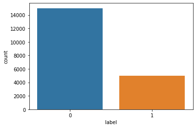

```python
# Seaborn count plot
sns.countplot(x="label", data=df)
plt.show()
```

More booking counts with safety trips

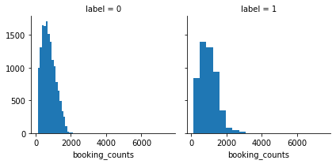

```python
# Seaborn facetgrid
g = sns.FacetGrid(df, col='label')
g.map(plt.hist, 'booking_counts', bins=20)
plt.show()
```

When the speed is faster, there are more trips being marked as safe than dagerous, which is a bit weird

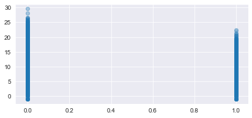

```python
# Set the backgrou to darkgrid
sns.set_style('darkgrid')
# Make th dots a bit transparent
alpha = alpha_scatterplot = 0.2
alpha_bar_chart = 0.55
# Now plot for the figure using scatter
fig = plt.figure(1, figsize=(15, 3))
ax = plt.subplot(121)
plt.scatter(df.label, df.Speed, alpha=alpha_scatterplot)
zero, one = df.label.value_counts()
```

The speed does not affect a lot whether a trip will be marked as safe or dangerous

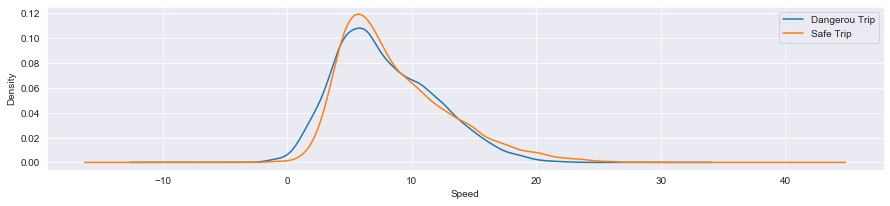

```python
def speed_kde_plot(col):
    # Plot the first figure and set the size of the figure
    plt.figure(1,figsize=(15,3))
    df[col][df.label == 1].plot(kind='kde')
    df[col][df.label == 0].plot(kind='kde')
    # sets our legend for our graph.
    plt.legend(('Dangerou Trip', 'Safe Trip'),loc='best')
    plt.xlabel(col)
# Call the function to plot the distribution plot
speed_kde_plot('Speed')
```

For booking counts below 1k, the more the booking the safer the trip, however it is ther other way round after the interction at about 1 k.

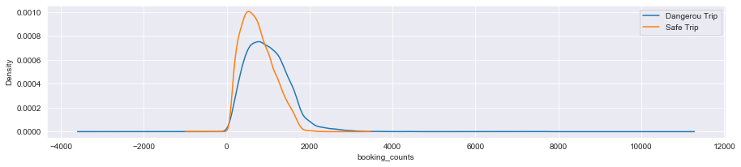

```python
speed_kde_plot('booking_counts')
```

The accuracy column does not seem to affect whethre the trip is safe or not.

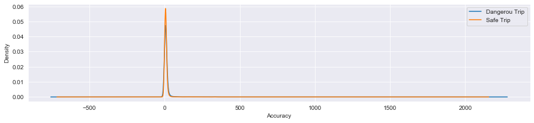

```python
speed_kde_plot('Accuracy')
```

Define a function that prints out the max, min and median value of a column in df

```python
def min_max_median(column):
    # Display the statistics of the selected column
    print('Min Value of {}: {}'.format(column, df[column].max()))
    print('Max Value of {}: {}'.format(column, df[column].min()))
    print('Median Value of {}: {}'.format(column, df[column].median()))
```

# Excluding Outliers

## Accuracy

The distribution of the accuracy column is very skewed.

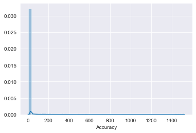

```python
# Searborn  distribution plot
sns.distplot(df['Accuracy'])
plt.show()
```

Call the function to display statistics about the selected column

```python
min_max_median('Accuracy')
```

[output not shown]

From the x-axis above we can observe that most the data lays below 200

```python
df['Accuracy'][df['Accuracy']>200].shape
```

```
(113,)
```

Removes outliers that are higher than 30

```python
df = df[df['Accuracy']<30]
df.shape
```

```
(19495, 13)
```

Distribution plot after removing outliers is more smooth

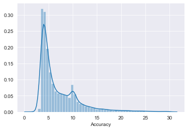

```python
sns.distplot(df['Accuracy'])
plt.show()
```

## Bearing

The distribution curve for the bearing is quite normalized

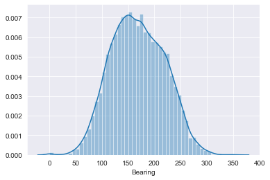

```python
sns.distplot(df['Bearing'])
plt.show()
```

## acceleration_x

The distribution for acceleration_x is quite normalized but the deviation may be a bit high

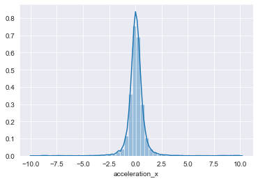

```python
sns.distplot(df['acceleration_x'])
```

Remove outliers that are below -4 or above 4

```python
df = df[(df['acceleration_x']>-4) & (df['acceleration_x']<4)]
df.shape
```

```
(19304, 13)
```

The distritbution curve is more normalized now.

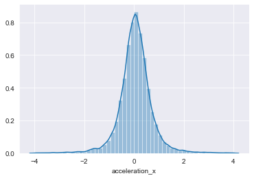

```python
sns.distplot(df['acceleration_x'])
plt.show()
```

# acceleration_y

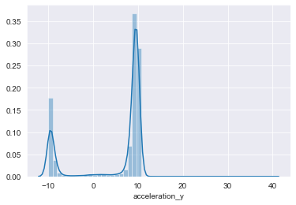

```python
sns.distplot(df['acceleration_y'])
plt.show()
```

```python
df = df[df['acceleration_y']<11]
df.shape
```

```
(19287, 13)
```

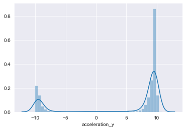

```python
sns.distplot(df['acceleration_y'])
plt.show()
```

## acceleration_z

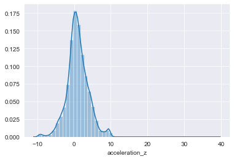

```python
sns.distplot(df['acceleration_z'])
plt.show()
```

```python
df = df[df['acceleration_z'] < 12]
```

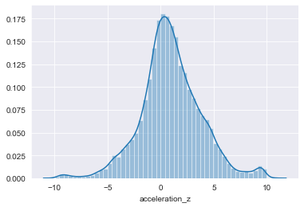

```python
sns.distplot(df['acceleration_z'])
plt.show()
```

## gyro_x, gyro_y

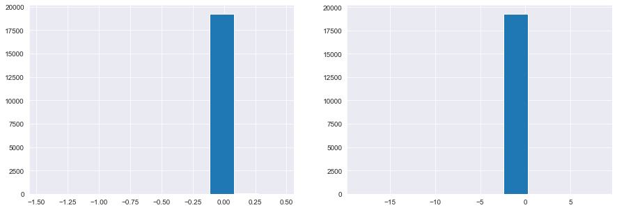

```python
def dist_plot(first_plot, second_plot):
    # Plot for the figure 1
    plt.figure(1, figsize=(15,5))
    # Add in the first subplot
    plt.subplot(121)
    # Plot for the histogram
    plt.hist(df[first_plot])
    # Do the same for the second subplot
    plt.subplot(122)
    plt.hist(df[second_plot])
    plt.show()
dist_plot('gyro_x','gyro_y')
```

Excluding outliers

```python
df = df[(df['gyro_x']>-0.10) & (df['gyro_x']<0.10)]
df = df[(df['gyro_y']>-0.10) & (df['gyro_y']<0.10)]
```

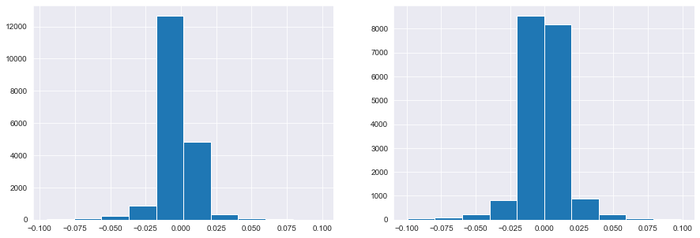

```python
dist_plot('gyro_x','gyro_y')
```

```python
df.shape
```

```
(19117, 13)
```

## Gyro_z, second

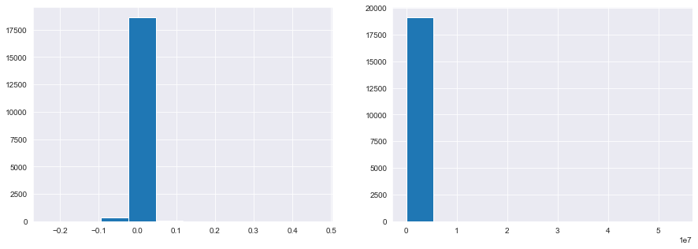

```python
dist_plot('gyro_z','second')
```

Instead of skewed as before, the histograms are more normalized now.

```python
df = df[(df['gyro_z']>-0.1) & (df['gyro_z']<0.10)]
df = df[(df['second']>10) & (df['second']<1500)]
```

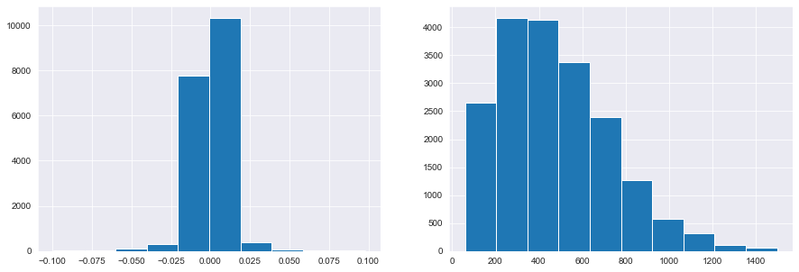

```python
dist_plot('gyro_z','second')
```

# Speed, booking_counts

For the histgrams that are already very towards normalization, we don't need to do anything.

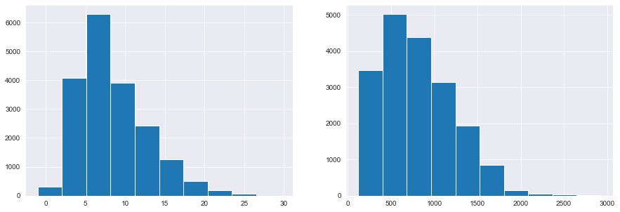

```python
dist_plot('Speed','booking_counts')
```

```python
df = df[(df['Speed']>=0) & (df['Speed']<28)]
df = df[(df['booking_counts']>0) & (df['booking_counts']<2800)]
```

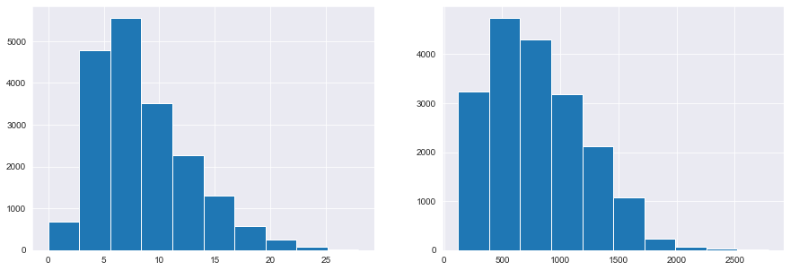

```python
dist_plot('Speed','booking_counts')
```

data shape after removing outliers

```python
df.shape
```

```
(19026, 13)
```

Generate more features for the neural network to learn

```python
# ###Distance
df['distance']=df['Speed']*df['second']
```

Generate for speed in different directions

```python
###Speed
df['speed_x']=df['acceleration_x']*df['second']
df['speed_y']=df['acceleration_y']*df['second']
df['speed_z']=df['acceleration_z']*df['second']
df['speed_xy']=np.sqrt(df['speed_x']**2+df['speed_y']**2)
df['speed_xz']=np.sqrt(df['speed_x']**2+df['speed_z']**2)
df['speed_yz']=np.sqrt(df['speed_z']**2+df['speed_y']**2)
df['speed_xyz']=np.sqrt(df['speed_x']**2+df['speed_y']**2+df['speed_z']**2)
```

```python
df['rad_x']=df['gyro_x']*df['second']
df['rad_y']=df['gyro_y']*df['second']
df['rad_z']=df['gyro_z']*df['second']
df['rad_xy']=np.sqrt(df['rad_x']**2+df['rad_y']**2)
df['rad_xz']=np.sqrt(df['rad_x']**2+df['rad_z']**2)
df['rad_yz']=np.sqrt(df['rad_z']**2+df['rad_y']**2)
df['rad_xyz']=np.sqrt(df['rad_x']**2+df['rad_y']**2+df['rad_z']**2)
```

```python
###Acceleration
df['acc_xy']=np.sqrt(df['acceleration_x']**2+df['acceleration_y']**2)
df['acc_xz']=np.sqrt(df['acceleration_x']**2+df['acceleration_z']**2)
df['acc_yz']=np.sqrt(df['acceleration_z']**2+df['acceleration_y']**2)
df['acc_xyz']=np.sqrt(df['acceleration_x']**2+df['acceleration_y']**2+df['acceleration_z']**2)
```

```python
###Gyro
df['gyro_xy']=np.sqrt(df['gyro_x']**2+df['gyro_y']**2)
df['gyro_xz']=np.sqrt(df['gyro_x']**2+df['gyro_z']**2)
df['gyro_yz']=np.sqrt(df['gyro_z']**2+df['gyro_y']**2)
df['gyro_xyz']=np.sqrt(df['gyro_x']**2+df['gyro_y']**2+df['gyro_z']**2)
```

```python
df['acc_gyro_x']=df['acceleration_x']*df['gyro_x']
df['acc_gyro_y']=df['acceleration_y']*df['gyro_y']
df['acc_gyro_z']=df['acceleration_z']*df['gyro_z']
df['acc_gyro_xy']=np.sqrt(df['acc_gyro_x']**2+df['acc_gyro_y']**2)
df['acc_gyro_xz']=np.sqrt(df['acc_gyro_x']**2+df['acc_gyro_z']**2)
df['acc_gyro_yz']=np.sqrt(df['acc_gyro_z']**2+df['acc_gyro_y']**2)
df['acc_gyro_xyz']=np.sqrt(df['acc_gyro_x']**2+df['acc_gyro_y']**2+df['acc_gyro_z']**2)
```

After generating more features, we now have 43 columns

```python
df.shape
```

```
(19026, 43)
```

Drop label and ID column for training set. And assign the target column to df_test

```python
df_train=df.drop(['label','bookingID'],axis=1) # df.drop to drop columns
df_test=df['label']
```

Scale the training set and display the first 5 rows

```python
# Store the name of the headers into a variable
df_train_headers = df_train.columns
# Init the scaler
scaler = StandardScaler()
# Scale the df_train and transform it back to a dataframe
df_train = pd.DataFrame(scaler.fit_transform(df_train),columns=df_train_headers)
df_train.head()
```

|  | Accuracy | Bearing | acceleration_x | acceleration_y | acceleration_z | gyro_x | gyro_y | gyro_z | second | Speed | ... | gyro_xz | gyro_yz | gyro_xyz | acc_gyro_x | acc_gyro_y | acc_gyro_z | acc_gyro_xy | acc_gyro_xz | acc_gyro_yz | acc_gyro_xyz |
| --- | --- | --- | --- | --- | --- | --- | --- | --- | --- | --- | --- | --- | --- | --- | --- | --- | --- | --- | --- | --- | --- |
| 0 | -0.302981 | 1.041574 | 1.759387 | 0.527058 | 1.063511 | 0.617440 | 0.189757 | -0.133920 | 1.619710 | -0.706143 | ... | -0.284167 | -0.673398 | -0.528689 | 0.818762 | 0.282865 | -0.184241 | -0.606583 | -0.168032 | -0.643327 | -0.636515 |
| 1 | 0.261986 | -2.171226 | 0.427945 | 0.527373 | 1.109859 | 0.118553 | -0.138685 | -0.075160 | 1.345977 | 1.045265 | ... | -0.667645 | -0.671694 | -0.742969 | -0.005608 | -0.044039 | -0.125533 | -0.585669 | -0.312804 | -0.618571 | -0.621744 |
| 2 | 0.245017 | -0.851848 | 0.588481 | 0.586461 | 0.584769 | 0.140179 | -0.056928 | -0.070949 | 3.798308 | 1.129346 | ... | -0.671999 | -0.751863 | -0.811940 | 0.005537 | 0.032474 | -0.074759 | -0.683083 | -0.367159 | -0.715867 | -0.719017 |
| 3 | -0.796933 | 0.247434 | 0.954098 | 0.627609 | -0.208630 | 0.102504 | 0.038060 | -0.216036 | 0.200346 | -0.415440 | ... | -0.551651 | -0.696066 | -0.762583 | -0.028343 | 0.131906 | -0.019228 | -0.807185 | -0.425622 | -0.834613 | -0.837420 |
| 4 | -0.730412 | -0.745632 | -0.168886 | 0.624571 | -0.696804 | 0.692266 | -0.165789 | -1.011323 | 1.420999 | 1.823491 | ... | 0.245670 | -0.078390 | -0.122755 | -0.038527 | -0.088221 | 0.297351 | -0.529402 | -0.141836 | -0.550374 | -0.553548 |

5 rows × 41 columns

41 Features

```python
df_train.shape
```

```
(19026, 41)
```

1 Target

```python
df_test.shape
```

```
(19026,)
```

Display the correlation between each factors, to see which factors are more correlaated with label.\n

- seconds have the highest coorelation of whether the trip is dagerous

```python
# Using df.corr() method
df_corr = df.corr().sort_values(by='label', ascending=False)['label'] # Use pandas corr method to show correlations
df_corr
```

```
label             1.000000
second            0.293460
speed_xyz         0.283431
speed_yz          0.282493
speed_xy          0.248593
booking_counts    0.228388
speed_xz          0.204861
distance          0.153597
rad_xyz           0.142463
rad_yz            0.134377
rad_xy            0.133659
rad_xz            0.132825
speed_z           0.090521
speed_y           0.086305
acc_gyro_xz       0.072778
acc_xz            0.072342
acceleration_z    0.045843
bookingID         0.036605
gyro_xz           0.033022
gyro_x            0.032357
gyro_xyz          0.022061
rad_x             0.021821
Accuracy          0.021803
gyro_yz           0.017811
gyro_xy           0.014624
speed_x           0.007107
acc_gyro_xyz      0.003769
acc_gyro_yz       0.002992
acc_gyro_y        0.002022
acceleration_y    0.001856
acc_gyro_x       -0.004965
acceleration_x   -0.006220
gyro_z           -0.009576
rad_y            -0.011011
acc_gyro_xy      -0.011875
gyro_y           -0.012168
rad_z            -0.014822
acc_gyro_z       -0.015464
Bearing          -0.020528
Speed            -0.068724
acc_xyz          -0.070190
acc_yz           -0.073763
acc_xy           -0.094118
Name: label, dtype: float64
```

Split the dataset into training and testing sets

```python
# Using train_test_split function
X_train, X_test, y_train, y_test = train_test_split(df_train,df_test)
```

# IV. Machine Learning Model Trainning

```python
class ml_models_training:
    # Init the class with 2 properties
    def __init__(self):
        # Store the different classifiers into a property
        self.models = [
            ExtraTreesClassifier(random_state=0),
            DecisionTreeClassifier(random_state=2),
            OneVsRestClassifier(RandomForestClassifier(random_state=0)),
            PassiveAggressiveClassifier(random_state=0),
            GaussianNB(),
            SVC(random_state=0),
            LogisticRegression(random_state=0),
            KNeighborsClassifier(),
            RandomForestClassifier(),
            DummyClassifier(random_state=0),
            AdaBoostClassifier(random_state=0),
            BaggingClassifier(random_state=0),
            GradientBoostingClassifier(random_state=0)
        ]
        # Store the names of the classifiers into another property
        self.model_names = [
            'ExtraTreesClassifier', 'DecisionTreeClassifier', 'OneVsRestClassifier',
            'PassiveAggressiveClassifier', 'GaussianNB', 'SVC', 'LogistiRegression',
            'KNeighborsClassifer', 'RandomForestClassifer', 'DummyClassifer',
            'AdaBoostClassifier', 'BaggingClassifier',
            'GradientBoostingClassifier'
        ]
    # Function to train and test to see model scores
    def model_selection(self):
        # Init arrays to store name and scores for training
        name_list = []
        scores_list = []
        training_scores = []
        # Loop through all classifiers
        for model, model_name in zip(self.models, self.model_names):
            # Train the model and append the scores
            model.fit(X_train, y_train)
            name_list.append(model_name)
            scores_list.append(model.score(X_test, y_test))
            training_scores.append(model.score(X_train, y_train))
        # Display the scores in a data frame
        return pd.DataFrame({'Model Names': name_list, 'Model Training Scores': training_scores, 'Model Testing Scores': scores_list})

ml_models = ml_models_training()
```

- Showing Training and Testing scores together
- Some of the classifiers overfit themselvels
- We will choose GradientBoostingClassifier as it is not overfitted and it performs the best for testings

```python
ml_models.model_selection()
```

|  | Model Names | Model Training Scores | Model Testing Scores |
| --- | --- | --- | --- |
| 0 | ExtraTreesClassifier | 1.000000 | 0.772125 |
| 1 | DecisionTreeClassifier | 1.000000 | 0.675426 |
| 2 | OneVsRestClassifier | 1.000000 | 0.777170 |
| 3 | PassiveAggressiveClassifier | 0.685472 | 0.674795 |
| 4 | GaussianNB | 0.730044 | 0.735127 |
| 5 | SVC | 0.790104 | 0.772966 |
| 6 | LogistiRegression | 0.776438 | 0.779693 |
| 7 | KNeighborsClassifer | 0.808816 | 0.746689 |
| 8 | RandomForestClassifer | 0.999930 | 0.777381 |
| 9 | DummyClassifer | 0.634873 | 0.631701 |
| 10 | AdaBoostClassifier | 0.777700 | 0.774017 |
| 11 | BaggingClassifier | 0.976102 | 0.755939 |
| 12 | GradientBoostingClassifier | 0.794239 | 0.780534 |

# V. Machine Learning Model Tuning

Manual Tuning

```python
class GBC_model_tunning:
    # Init the tuning class with 5 properties
    def __init__(self, random_state=0, learning_rate=0.1, n_estimators=100, max_depth=3):
        self.random_state = random_state
        self.learning_rate = learning_rate
        self.n_estimators = n_estimators
        self.max_depth = max_depth
        self.best_score = 0
    # Function to visualize the tuning process
    def visualize_process(self, tmp_score, x, y, title):
        plt.plot(range(len(tmp_score)), tmp_score)
        plt.xlabel(x)
        plt.ylabel(y)
        plt.title(title)
        plt.show()
    # Print out the best tuning scores and their respective values
    def display_best_score(self,parameter_name, score,parameter_val):
        print('Highest Accuracy Score Obtained While Tuning the {}: {}'.format(
            parameter_name, score))
        print('Best {} to obtain the highest score: {}'.format(
            parameter_name, parameter_val))
    # Function to tune random_state
    def tuning_random_state(self, random_state_range):
        tmp_score = []
        # Loop through all random_state passed in
        for rs in random_state_range:
            model = GradientBoostingClassifier(random_state=rs)
            model.fit(X_train, y_train)
            tmp_score.append(model.score(X_test, y_test))
        # Visualize the process
        self.visualize_process(tmp_score, "random_state",
                               'Accuracy', 'Tunning Accuracy for random_state')
        best_score = max(tmp_score)
        best_score_index = tmp_score.index(best_score)
        # Modify properties for the best random_state
        self.random_state = random_state_range[best_score_index]
        # Display the best score
        self.display_best_score('random_state',best_score,self.random_state)
    # Function to tune learning_rate
    def tuning_learning_rate(self, learning_rate_range):
        tmp_score = []
        for lr in learning_rate_range:
            model = GradientBoostingClassifier(
                learning_rate=lr, random_state=self.random_state)
            model.fit(X_train, y_train)
            tmp_score.append(model.score(X_test, y_test))
        self.visualize_process(tmp_score, "learning_rate",
                               'Accuracy', 'Tunning Accuracy for learning_rate')
        best_score = max(tmp_score)
        best_score_index = tmp_score.index(best_score)
        self.learning_rate = learning_rate_range[best_score_index]
        # Display the best score
        self.display_best_score('learning_rate',best_score,self.learning_rate)
    # Function to tune n_estimators
    def tuning_n_estimators(self, n_estimators_range):
        tmp_score = []
        # Loop through all the range passed in
        for ne in n_estimators_range:
            model = GradientBoostingClassifier(
                learning_rate=self.learning_rate, n_estimators=ne, random_state=self.random_state)
            model.fit(X_train, y_train)
            tmp_score.append(model.score(X_test, y_test))
        self.visualize_process(tmp_score, "n_estimators",
                               'Accuracy', 'Tunning Accuracy for n_estimators')
        best_score = max(tmp_score)
        best_score_index = tmp_score.index(best_score)
        self.n_estimators = n_estimators_range[best_score_index]
        # Display the best score
        self.display_best_score('n_estimators',best_score,self.n_estimators)
        self.best_score = best_score

GBC_model = GBC_model_tunning()
```

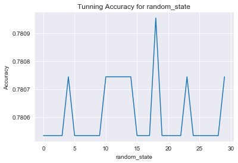

```
Highest Accuracy Score Obtained While Tuning the random_state: 0.7809543830145049
Best random_state to obtain the highest score: 18
```

```python
GBC_model.tuning_random_state(range(0,30))
```

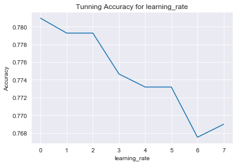

```
Highest Accuracy Score Obtained While Tuning the learning_rate: 0.7809543830145049
Best learning_rate to obtain the highest score: 0.1
```

```python
GBC_model.tuning_learning_rate(np.arange(10,50,5)/100)
```

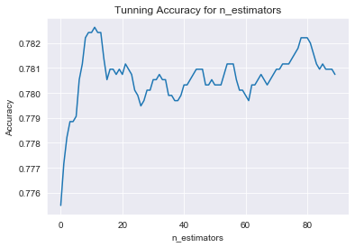

```
Highest Accuracy Score Obtained While Tuning the n_estimators: 0.7826361151986546
Best n_estimators to obtain the highest score: 21
```

```python
GBC_model.tuning_n_estimators(np.arange(10,100,1))
```

Display the set of manually tuned parameters.

```python
pd.DataFrame({'Parameter Name':['random_state','learning_rate','n_estimators'],'Tunned Value':[GBC_model.random_state,
                                                                                             GBC_model.learning_rate,
                                                                                             GBC_model.n_estimators]})
```

|  | Parameter Name | Tunned Value |
| --- | --- | --- |
| 0 | random_state | 18.000000 |
| 1 | learning_rate | 0.100000 |
| 2 | n_estimators | 21.000000 |

Now let's try to use SerachCV to tune.

- Pros: Easier to tune
- Cons: Cannot visualize the tuning history

```python
GBC = GradientBoostingClassifier()
parameters = {'learning_rate':np.arange(10,100,5)/100,'random_state':range(0,100),'n_estimators':range(0,100)}
clf = RandomizedSearchCV(GBC, parameters)
clf.fit(X_train, y_train)
clf.best_score_
```

```
0.7734945278221748
```

```python
clf.best_params_
```

```
{'random_state': 30, 'n_estimators': 54, 'learning_rate': 0.25}
```

```python
tuned_para_name = list(clf.best_params_.keys())
tuned_para_name.append('Accuracy Score')
tuned_para_name
```

```
['random_state', 'n_estimators', 'learning_rate', 'Accuracy Score']
```

```python
tuned_para_val=list(clf.best_params_.values())
tuned_para_val.append(clf.best_score_)
tuned_para_val
```

```
[30, 54, 0.25, 0.7734945278221748]
```

```python
manual_tuned_val=[GBC_model.random_state,GBC_model.n_estimators,GBC_model.learning_rate,GBC_model.best_score]
manual_tuned_val
```

```
[18, 21, 0.1, 0.7826361151986546]
```

Since the results are similar but the munal tuned is slightly higher, we will use the second set of params

```python
pd.DataFrame({'RandomizedSearchCV':tuned_para_val,'Manual Tuned Params':manual_tuned_val},index=tuned_para_name)
```

|  | RandomizedSearchCV | Manual Tuned Params |
| --- | --- | --- |
| random_state | 30.000000 | 18.000000 |
| n_estimators | 54.000000 | 21.000000 |
| learning_rate | 0.250000 | 0.100000 |
| Accuracy Score | 0.773495 | 0.782636 |

# VI. Machine Learning Model Evaluation

Init the best model

```python
GBC = GradientBoostingClassifier(random_state=18,n_estimators=21,learning_rate=0.1)
GBC.fit(X_train,y_train)
```

```
GradientBoostingClassifier(ccp_alpha=0.0, criterion='friedman_mse', init=None,
                           learning_rate=0.1, loss='deviance', max_depth=3,
                           max_features=None, max_leaf_nodes=None,
                           min_impurity_decrease=0.0, min_impurity_split=None,
                           min_samples_leaf=1, min_samples_split=2,
                           min_weight_fraction_leaf=0.0, n_estimators=21,
                           n_iter_no_change=None, presort='deprecated',
                           random_state=18, subsample=1.0, tol=0.0001,
                           validation_fraction=0.1, verbose=0,
                           warm_start=False)
```

Our model is giving relatively accurate predictions as shown in the confusion matrix. We have 18 correct predictions out of 20

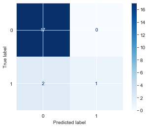

```python
plot_confusion_matrix(GBC, X_test[:20], y_test[:20],cmap=plt.cm.Blues)
plt.show()
```

Compare the predicted and true label for the first 20 rows of the test set. Only 2 trips is predicted wrongly.

```python
pd.DataFrame({'Predicted Labels':GBC.predict(X_test[:20]),'True Labels':y_test[:20]})
```

|  | Predicted Labels | True Labels |
| --- | --- | --- |
| 18191 | 0 | 0 |
| 255 | 0 | 0 |
| 5039 | 0 | 0 |
| 19273 | 0 | 0 |
| 2303 | 0 | 0 |
| 15303 | 0 | 0 |
| 2662 | 0 | 0 |
| 14340 | 0 | 0 |
| 19973 | 0 | 0 |
| 15859 | 1 | 1 |
| 11126 | 0 | 1 |
| 9998 | 0 | 0 |
| 16813 | 0 | 0 |
| 17073 | 0 | 0 |
| 14856 | 0 | 0 |
| 18310 | 0 | 0 |
| 16047 | 0 | 0 |
| 5405 | 0 | 1 |
| 16155 | 0 | 0 |
| 19831 | 0 | 0 |

# VII. Deep Learning Model Training

Init parent model

```python
class model_init:
    def __init__(self):
        self.model = Sequential()
```

Init nn model

```python
class neural_network_model(model_init):
    # Init the model properties
    def __init__(self):
        super().__init__()
        self.early_stopping = EarlyStopping(monitor='val_loss', patience=5)
    # Function to set up model
    def setup_model(self,activation='tanh',loss_activation='sigmoid',layers=0,neurons=10,input_neuron=1000):
        self.model.add(Dense(input_neuron, input_shape=(41, ), activation=activation))
        for i in range(layers):
            self.model.add(Dense(neurons, activation='relu'))
            self.model.add(BatchNormalization())
            self.model.add(Dropout(0.2))
        self.model.add(Dense(1, activation=loss_activation))
        self.model.add(Dense(1, activation=loss_activation))
        self.model.compile(loss='binary_crossentropy',
                      optimizer='adam', metrics=['accuracy'])
        return self.model
    # Function to train the model
    def train_model(self):
        # Store history for visualization
        history = self.model.fit(X_train, y_train, validation_data=(X_test, y_test),
                                 epochs=1000, callbacks=[self.early_stopping])
        # Plot for the tuning history
        plt.figure(1, figsize=(20,5))
        plt.subplot(121)
        plt.plot(history.history['accuracy'])
        plt.plot(history.history['val_accuracy'])
        plt.title('model accuracy')
        plt.ylabel('accuracy')
        plt.xlabel('epoch')
        plt.legend(['train', 'test'], loc='upper left')
        # summarize history for loss
        plt.subplot(122)
        plt.plot(history.history['loss'])
        plt.plot(history.history['val_loss'])
        plt.title('model loss')
        plt.ylabel('loss')
        plt.xlabel('epoch')
        plt.legend(['train', 'test'], loc='upper left')
        plt.show()
    # Evalue the model score
    def evaluate_model(self):
        # Final evaluation of the model
        scores = self.model.evaluate(X_test, y_test, verbose=0)
        print("Loss Error: %.2f%%" % (100-scores[1]*100))
    # Show model summary
    def summarise_model(self):
        self.model.summary()
# Init the instance
base_model = neural_network_model()
```

Train and evaluate the model

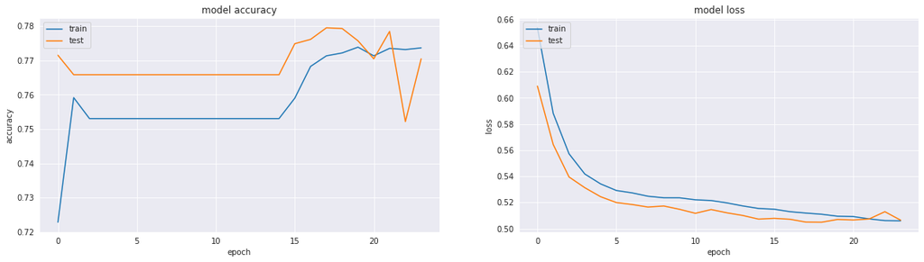

```
Loss Error: 22.96%
```

```python
base_model.setup_model()
base_model.train_model()
base_model.evaluate_model()
```

# VIII. Deep Learning Model Tuning

In this section we try to tune the hyper-parameters of the neural network, however due to the limit of the GPU power. We cannot search for all possible layers and neurons or else we could get better results.

```python
base_model = neural_network_model()
# store the function of the class into a variable, without bracket to call the funcion
model_tune_fn = base_model.setup_model
# using the module in keras to transfer the nn model from keras to sklearn for sklearn operations
model = KerasClassifier(build_fn=model_tune_fn, epochs=10, batch_size=100)
# parameters to tune
params = dict(activation=['relu', 'tanh'], loss_activation=[
              'sigmoid', 'softmax'], layers=[0, 1], neurons=[32, 64])
# use randomized searchCV to tune the hyperparameters
random_search = RandomizedSearchCV(model, params, cv=3)
# Train
random_search_results = random_search.fit(X_train, y_train)
# Show the results
print("Error: {}%".format(100-random_search_results.best_score_*100))
print('Best accuracy score obtained: {}'.format(
    random_search_results.best_score_))
print('Best params obtained: {}'.format(random_search_results.best_params_))
```

```
Error: 24.206231037775666%
Best accuracy score obtained: 0.7579376896222433
Best params obtained: {'neurons': 64, 'loss_activation': 'sigmoid', 'layers': 1, 'activation': 'relu'}
```

# IX. Deep Learning Model Evaluation

Here we use the tuned hyper-parameters for model evaluation. However this may not be the most optimized set of parameters as we only tried a few combinations due to the limit of the CPU power.

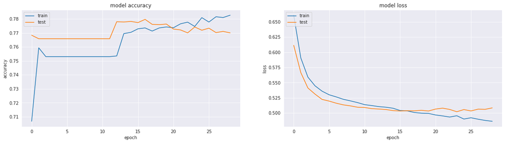

```
Loss Error: 23.00%
```

```python
tuned_model = neural_network_model()
tuned_model.setup_model(neurons=64,loss_activation='sigmoid',layers=1,activation='relu')
tuned_model.train_model()
tuned_model.evaluate_model()
```